# 클린업 1주차 신유정

```r
rm(list=ls())

library(ggplot2)
library(dplyr)
library(plyr)
library(data.table)
library(tidyverse)
library(magrittr)
setwd("C:/Users/shinyoojeong/Desktop/패키지과제/")
```

# 1. 기존의 코드를 다시 코딩해보자

```r
# data <- read.csv("데이터0.csv")
data <- fread("데이터0.csv")

# data$Petal.Length <- NULL
data %<>% select(-Petal.Length)

# data <- data[data$Petal.Width <= 1.800, ]
data %<>% filter(Petal.Width <= 1.800)

# data$Sepal_mean <- mean(data$Sepal.Length)
# data$Sepal_sd <- sqrt(var(data$Sepal.Length))
data %<>% mutate(Sepal_mean = mean(Sepal.Length),
                 Sepal_sd = sqrt(var(Sepal.Length)))


# data$Sepal.Width_mean_each <- NA
# data$Sepal.Width_mean_each[data$Species == "virginica"] <- mean(data$Sepal.Width[data$Species == "virginica"])
# data$Sepal.Width_mean_each[data$Species == "versicolor"] <- mean(data$Sepal.Width[data$Species == "versicolor"])
# data$Sepal.Width_mean_each[data$Species == "setosa"] <- mean(data$Sepal.Width[data$Species == "setosa"])
data$Species %<>% as.factor
data <- data %>% dplyr::group_by(Species) %>% dplyr::mutate(Sepal.Width_mean_each = mean(Sepal.Width))

# data$num <- NA
# data$num[data$Species == "virginica"] <- length(data$num[data$Species == "virginica"])
# data$num[data$Species == "versicolor"] <- length(data$num[data$Species == "versicolor"])
# data$num[data$Species == "setosa"] <- length(data$num[data$Species == "setosa"])
data_num <- data %>% group_by(Species) %>% dplyr::summarise(num=n())
data <- left_join(data, data_num, by="Species")

# data <- data[data$Sepal.Length %>% order(decreasing = T), ]
data %<>% arrange(desc(Sepal.Length))

# data$Species <- as.character(data$Species)
# data$Species[data$Species == "virginica"] <- "VI"
# data$Species[data$Species == "versicolor"] <- "VE"
# data$Species[data$Species == "setosa"] <- "SE"
# data$Species <- as.factor(data$Species)
data$Species %<>% revalue(c('virginica'='VI','versicolor'='VE','setosa'='SE')) %>% as.factor

# colnames(data)[colnames(data) == "Species"] <- "name"
data %<>% dplyr::rename(name=Species)

glimpse(data)
```

```
## Observations: 116
## Variables: 8
## Groups: name [3]
## $ Sepal.Length          <dbl> 7.3, 7.2, 7.2, 7.0, 6.9, 6.8, 6.7, 6.7, 6.7, ...
## $ Sepal.Width           <dbl> 2.9, 3.2, 3.0, 3.2, 3.1, 2.8, 3.1, 3.0, 3.1, ...
## $ Petal.Width           <dbl> 1.8, 1.8, 1.6, 1.4, 1.5, 1.4, 1.4, 1.7, 1.5, ...
## $ name                  <fct> VI, VI, VI, VE, VE, VE, VE, VE, VE, VI, VE, V...
## $ Sepal_mean            <dbl> 5.590517, 5.590517, 5.590517, 5.590517, 5.590...
## $ Sepal_sd              <dbl> 0.699811, 0.699811, 0.699811, 0.699811, 0.699...
## $ Sepal.Width_mean_each <dbl> 2.825, 2.825, 2.825, 2.770, 2.770, 2.770, 2.7...
## $ num                   <int> 16, 16, 16, 50, 50, 50, 50, 50, 50, 16, 50, 5...
```

# CHAPTER 1. 전처리

### (1) 데이터1.csv를 불러오고 그 str 및 summary를 확인해보자

```r
data1 <- fread("데이터1.csv")
data1 %<>% as.data.frame()

str(data1)
```

```
## 'data.frame':    59009 obs. of  32 variables:
##  $ click                 : int  0 0 0 0 0 0 0 0 0 0 ...
##  $ event_datetime        : chr  "2019-10-10 10:56:22.630" "2019-10-09 03:45:41.290" "2019-10-03 08:44:09.192" "2019-10-09 00:02:36.144" ...
##  $ bid_id                : chr  "UC9cToa1lW" "fRWvRbFrFm" "OUXau6CTY8" "nXg9gWWdY6" ...
##  $ ssp_id                : chr  "ddtzah8tWp" "nwf1A3O5cO" "VKAHCb2KFB" "M6QaRvdZ8h" ...
##  $ campaign_id           : chr  "6MHXVqZ5r7" "soNcvXzOZg" "7Kwt6e0pY7" "RxEczLJS45" ...
##  $ adset_id              : chr  "9Vs8t2QPht" "XsxDfbHZk4" "AG7qEYSHUh" "jooulmYwop" ...
##  $ placement_type        : chr  "1pcQ3RJgQt" "kIeE1J0KCa" "kIeE1J0KCa" "kIeE1J0KCa" ...
##  $ media_id              : chr  "hLR1pJk4Us" "sRqCheOKW4" "hLuV0aqEVp" "Cp0TOgEAEB" ...
##  $ media_name            : chr  "Rmr6xB6bN1" "n0p3m00ieQ" "Xbdchs5uK3" "EajTk3ilNf" ...
##  $ media_bundle          : chr  "lxiZbb3bG8" "LfFPsJWJSf" "0tlqbS6Nf5" "AFk4AYEOyt" ...
##  $ media_domain          : chr  "pjBT3sDGbH" "pjBT3sDGbH" "pjBT3sDGbH" "pjBT3sDGbH" ...
##  $ publisher_id          : chr  "ZKL5lpzDZo" "dShknap9uf" "FpOvhbPDXd" "vjSjiBHBO7" ...
##  $ publisher_name        : chr  "Abg0jYuxSE" "N8djnVWnYo" "BnqjbSLXhH" "dDz4Byog6d" ...
##  $ device_ifa            : chr  "N8iTdgNfWN" "0BVuqZ2Gb2" "xyFIR0yYgF" "q11EDogjCE" ...
```

[output cut: 18 more lines]

```r
summary(data1)
```

```
##      click        event_datetime        bid_id             ssp_id
##  Min.   :0.0000   Length:59009       Length:59009       Length:59009
##  1st Qu.:0.0000   Class :character   Class :character   Class :character
##  Median :0.0000   Mode  :character   Mode  :character   Mode  :character
##  Mean   :0.1147
##  3rd Qu.:0.0000
##  Max.   :1.0000
##
##  campaign_id          adset_id         placement_type       media_id
##  Length:59009       Length:59009       Length:59009       Length:59009
##  Class :character   Class :character   Class :character   Class :character
##  Mode  :character   Mode  :character   Mode  :character   Mode  :character
##
##
##
##
##   media_name        media_bundle       media_domain       publisher_id
##  Length:59009       Length:59009       Length:59009       Length:59009
##  Class :character   Class :character   Class :character   Class :character
##  Mode  :character   Mode  :character   Mode  :character   Mode  :character
##
##
##
##
##  publisher_name      device_ifa         device_os         device_os_version
##  Length:59009       Length:59009       Length:59009       Length:59009
##  Class :character   Class :character   Class :character   Class :character
##  Mode  :character   Mode  :character   Mode  :character   Mode  :character
##
##
##
##
##  device_model       device_carrier     device_make
##  Length:59009       Length:59009       Length:59009
##  Class :character   Class :character   Class :character
##  Mode  :character   Mode  :character   Mode  :character
##
##
##
##
```

[output cut: 17 more lines]

```
##  Length:59009       Length:59009       Length:59009       Length:59009
##  Class :character   Class :character   Class :character   Class :character
##  Mode  :character   Mode  :character   Mode  :character   Mode  :character
##
##
##
##
##  predicted_house_price asset_index
##  Min.   :   320        Mode:logical
##  1st Qu.:  8750        NA's:59009
##  Median : 16300
##  Mean   : 22408
##  3rd Qu.: 28000
##  Max.   :320000
##  NA's   :6506
```

### (2) 각 변수마다 유니크한 값들이 몇 개인지 알아보자

```r
uni_num <- NULL

for (i in 1:ncol(data1)) {
  uni <- data1[, i] %>% unique %>% length
  uni_num <- c(uni_num, uni)
}
# 각 변수마다의 유니크한 값의 개수 기록

# column name이랑 결합
uni_set <- cbind(colnames(data1), uni_num)
uni_set
```

```
##                                uni_num
##  [1,] "click"                  "2"
##  [2,] "event_datetime"         "59004"
##  [3,] "bid_id"                 "59009"
##  [4,] "ssp_id"                 "17"
##  [5,] "campaign_id"            "175"
##  [6,] "adset_id"               "758"
##  [7,] "placement_type"         "4"
##  [8,] "media_id"               "1064"
##  [9,] "media_name"             "914"
## [10,] "media_bundle"           "746"
## [11,] "media_domain"           "63"
## [12,] "publisher_id"           "571"
## [13,] "publisher_name"         "375"
## [14,] "device_ifa"             "38168"
```

[output cut: 18 more lines]

### (3) str, summary, 유니크한 값들의 숫자들의 정보를 보았을 때 지워야할 열을 지우고 그 이유를 간략하게 설명해보자

```r
data1 %<>% select(-device_os,-device_country, -asset_index)
```

device_os, device_country, asset_index 변수들은 하나의 값만 가지고 있기 때문에 삭제

### (4) age 변수 명목 변수로

```r
data1$age <- as.factor(data1$age)
```

### (5) 파생변수 만들어보자

### 5-1) event_datetime을 가지고 주말 여부와 요일, 일, 시간 변수를 만들기

```r
library(lubridate)
data1 %<>% mutate(date = day(data1$event_datetime),
                  day = wday(data1$event_datetime, label=T),
                  weekend = ifelse(day =="토"|day=="일", 'we', 'wd'),
                  hour = hour(data1$event_datetime))

data1$hour %<>% as.factor()
data1$date %<>% as.factor()

head(data1)
```

```
##   click          event_datetime     bid_id     ssp_id campaign_id   adset_id
## 1     0 2019-10-10 10:56:22.630 UC9cToa1lW ddtzah8tWp  6MHXVqZ5r7 9Vs8t2QPht
## 2     0 2019-10-09 03:45:41.290 fRWvRbFrFm nwf1A3O5cO  soNcvXzOZg XsxDfbHZk4
## 3     0 2019-10-03 08:44:09.192 OUXau6CTY8 VKAHCb2KFB  7Kwt6e0pY7 AG7qEYSHUh
## 4     0 2019-10-09 00:02:36.144 nXg9gWWdY6 M6QaRvdZ8h  RxEczLJS45 jooulmYwop
## 5     0 2019-10-01 08:55:44.034 k1bJQUXc70 nwf1A3O5cO  F2pclyuYiJ zcDsgE1Qdj
## 6     0 2019-10-06 11:27:20.431 FrgpN7jvMp VKAHCb2KFB  DxYurpVIvX LNTjEu4Ufg
##   placement_type   media_id media_name media_bundle media_domain publisher_id
## 1     1pcQ3RJgQt hLR1pJk4Us Rmr6xB6bN1   lxiZbb3bG8   pjBT3sDGbH   ZKL5lpzDZo
## 2     kIeE1J0KCa sRqCheOKW4 n0p3m00ieQ   LfFPsJWJSf   pjBT3sDGbH   dShknap9uf
## 3     kIeE1J0KCa hLuV0aqEVp Xbdchs5uK3   0tlqbS6Nf5   pjBT3sDGbH   FpOvhbPDXd
## 4     kIeE1J0KCa Cp0TOgEAEB EajTk3ilNf   AFk4AYEOyt   pjBT3sDGbH   vjSjiBHBO7
## 5     kIeE1J0KCa DWY9UMZ2fw WhhTLzeJT9   AFk4AYEOyt   pjBT3sDGbH   R4nPUBU2zA
## 6     WnrXFsYXNs fsa16ykahK Xbdchs5uK3   MkxRiLAcQH   pjBT3sDGbH   FpOvhbPDXd
##   publisher_name device_ifa device_os_version device_model device_carrier
```

[output cut: 41 more lines]

### 5-2) event_datetime과 click을 가지고 시간당 평균 클릭율 변수 만들기

```r
a <- data1 %>% group_by(date, hour, click) %>% dplyr::summarise(n=n()) %>% filter(click==0)
# 시간대별 클릭 안한 횟수
# 클릭 횟수로 계산하니까 아예 클릭 안한 경우엔 누락으로 처리돼서 클릭 안한 횟수를 기록하고 후에 전체 사건에서 클릭 안한 횟수 빼주는 식으로 계산함

b <- data1 %>% group_by(date, hour) %>% dplyr::summarise(n=n())  # 시간대별 사건수

b$click_ratio_byhour <- (b$n - a$n) / b$n
b <- select(b, -n)

data1 <- left_join(data1, b, by=c('date','hour'))
head(data1)
```

```
##   click          event_datetime     bid_id     ssp_id campaign_id   adset_id
## 1     0 2019-10-10 10:56:22.630 UC9cToa1lW ddtzah8tWp  6MHXVqZ5r7 9Vs8t2QPht
## 2     0 2019-10-09 03:45:41.290 fRWvRbFrFm nwf1A3O5cO  soNcvXzOZg XsxDfbHZk4
## 3     0 2019-10-03 08:44:09.192 OUXau6CTY8 VKAHCb2KFB  7Kwt6e0pY7 AG7qEYSHUh
## 4     0 2019-10-09 00:02:36.144 nXg9gWWdY6 M6QaRvdZ8h  RxEczLJS45 jooulmYwop
## 5     0 2019-10-01 08:55:44.034 k1bJQUXc70 nwf1A3O5cO  F2pclyuYiJ zcDsgE1Qdj
## 6     0 2019-10-06 11:27:20.431 FrgpN7jvMp VKAHCb2KFB  DxYurpVIvX LNTjEu4Ufg
##   placement_type   media_id media_name media_bundle media_domain publisher_id
## 1     1pcQ3RJgQt hLR1pJk4Us Rmr6xB6bN1   lxiZbb3bG8   pjBT3sDGbH   ZKL5lpzDZo
## 2     kIeE1J0KCa sRqCheOKW4 n0p3m00ieQ   LfFPsJWJSf   pjBT3sDGbH   dShknap9uf
## 3     kIeE1J0KCa hLuV0aqEVp Xbdchs5uK3   0tlqbS6Nf5   pjBT3sDGbH   FpOvhbPDXd
## 4     kIeE1J0KCa Cp0TOgEAEB EajTk3ilNf   AFk4AYEOyt   pjBT3sDGbH   vjSjiBHBO7
## 5     kIeE1J0KCa DWY9UMZ2fw WhhTLzeJT9   AFk4AYEOyt   pjBT3sDGbH   R4nPUBU2zA
## 6     WnrXFsYXNs fsa16ykahK Xbdchs5uK3   MkxRiLAcQH   pjBT3sDGbH   FpOvhbPDXd
##   publisher_name device_ifa device_os_version device_model device_carrier
```

[output cut: 41 more lines]

### 5-3) install_pack을 가지고 설치되어 있는 앱의 갯수 변수를 만들기

```r
data1$app_num <- sapply(strsplit(data1$install_pack, split = ","), length)
# strsplit 함수를 쓰면 ","을 기준으로 문자열을 나누면서 한 obs당 list의 한 칸?을 차지하게 됨 -> sapply로 나눠진 벡터 길이 구함

head(data1)
```

```
##   click          event_datetime     bid_id     ssp_id campaign_id   adset_id
## 1     0 2019-10-10 10:56:22.630 UC9cToa1lW ddtzah8tWp  6MHXVqZ5r7 9Vs8t2QPht
## 2     0 2019-10-09 03:45:41.290 fRWvRbFrFm nwf1A3O5cO  soNcvXzOZg XsxDfbHZk4
## 3     0 2019-10-03 08:44:09.192 OUXau6CTY8 VKAHCb2KFB  7Kwt6e0pY7 AG7qEYSHUh
## 4     0 2019-10-09 00:02:36.144 nXg9gWWdY6 M6QaRvdZ8h  RxEczLJS45 jooulmYwop
## 5     0 2019-10-01 08:55:44.034 k1bJQUXc70 nwf1A3O5cO  F2pclyuYiJ zcDsgE1Qdj
## 6     0 2019-10-06 11:27:20.431 FrgpN7jvMp VKAHCb2KFB  DxYurpVIvX LNTjEu4Ufg
##   placement_type   media_id media_name media_bundle media_domain publisher_id
## 1     1pcQ3RJgQt hLR1pJk4Us Rmr6xB6bN1   lxiZbb3bG8   pjBT3sDGbH   ZKL5lpzDZo
## 2     kIeE1J0KCa sRqCheOKW4 n0p3m00ieQ   LfFPsJWJSf   pjBT3sDGbH   dShknap9uf
## 3     kIeE1J0KCa hLuV0aqEVp Xbdchs5uK3   0tlqbS6Nf5   pjBT3sDGbH   FpOvhbPDXd
## 4     kIeE1J0KCa Cp0TOgEAEB EajTk3ilNf   AFk4AYEOyt   pjBT3sDGbH   vjSjiBHBO7
## 5     kIeE1J0KCa DWY9UMZ2fw WhhTLzeJT9   AFk4AYEOyt   pjBT3sDGbH   R4nPUBU2zA
## 6     WnrXFsYXNs fsa16ykahK Xbdchs5uK3   MkxRiLAcQH   pjBT3sDGbH   FpOvhbPDXd
##   publisher_name device_ifa device_os_version device_model device_carrier
```

[output cut: 41 more lines]

### (6) event_date_time과 같은 시간 데이터를 제외하고 모든 character 클래스를 factor 클래스로 바꾸자

```r
# character형 변수면 factor로, 아니면 냅두기
for (i in 1:ncol(data1)) {
  if (is.character(data1[,i])) {
    data1[,i] %<>% as.factor()
  } else {
    data1[,i] <- data1[,i]
  }
}

# 시간형 변수랑 트랜잭션 데이터는 다시 character로
data1$event_datetime %<>% as.character()
data1$install_pack %<>% as.character()
data1$cate_code %<>% as.character()

str(data1)
```

```
## 'data.frame':    59009 obs. of  35 variables:
##  $ click                 : int  0 0 0 0 0 0 0 0 0 0 ...
##  $ event_datetime        : chr  "2019-10-10 10:56:22.630" "2019-10-09 03:45:41.290" "2019-10-03 08:44:09.192" "2019-10-09 00:02:36.144" ...
##  $ bid_id                : Factor w/ 59009 levels "001IN9MgwB","001ZFEdhNa",..: 48010 20374 37626 35840 28487 20326 44561 16674 6629 30822 ...
##  $ ssp_id                : Factor w/ 17 levels "4rKKqEXsKn","5vVGidhbcl",..: 6 11 15 10 11 15 11 11 10 6 ...
##  $ campaign_id           : Factor w/ 175 levels "0atWS1rCZU","0cIRQG21u2",..: 17 133 20 127 58 52 116 116 39 144 ...
##  $ adset_id              : Factor w/ 758 levels "00MSDfpk0a","0cMyTSKd8O",..: 118 703 131 345 738 391 610 610 557 702 ...
##  $ placement_type        : Factor w/ 4 levels "1pcQ3RJgQt","kIeE1J0KCa",..: 1 2 2 2 2 4 2 2 2 1 ...
##  $ media_id              : Factor w/ 1064 levels "00OGU9Omqd","06lZPZ37Ml",..: 453 818 454 276 323 397 818 818 360 235 ...
##  $ media_name            : Factor w/ 914 levels "00DIh78MZC","02mP803Z7Z",..: 658 527 821 276 795 821 527 527 743 841 ...
##  $ media_bundle          : Factor w/ 746 levels "06e3evfsOR","0bt4ogIwyt",..: 415 399 8 128 128 430 399 399 209 262 ...
##  $ media_domain          : Factor w/ 63 levels "06zEa6svYv","1MAbsw2E9n",..: 40 40 40 40 40 40 40 40 40 40 ...
##  $ publisher_id          : Factor w/ 571 levels "01PtDPZj1F","06DdI8oNPW",..: 555 167 198 478 411 198 167 167 478 85 ...
##  $ publisher_name        : Factor w/ 375 levels "06rvaV5IG9","0MBXc6wmhA",..: 71 220 92 114 86 92 220 220 43 60 ...
##  $ device_ifa            : Factor w/ 38168 levels "00DmeMAWCI","00gSjnK6wx",..: 22177 146 35652 25775 10659 20088 27139 11121 31140 1248 ...
```

[output cut: 21 more lines]

## 보너스 문제

### 1. 트랜잭션 데이터인 cate_code 변수를 어떻게 사용할 수 있을까? 전처리는?

```r
# 카테고리가 있냐 없냐를 기준으로 one-hot encoding - 근데 이건 rank 정보가 무시되긴 함
# 전처리 과정 - cate_code 변수를 "," 기준으로 나누고 ';1'과 같은 rank 정보는 삭제. -> 카테고리가 있으면 1, 없으면 0으로 기록
# 코드는 너무 오래 걸려서 생략하겠습니다 ㅎㅎ

# 1/2/3/4/5 rank 개수 변수 - 근데 이건 별로 의미 없을 듯
```

### 2. 트랜잭션 데이터인 install_pack 변수를 어떻게 사용할 수 있을까? 전처리는?

```r
# install_pack 변수 전체에서 unique한 값 개수 구해보기
app_list <- strsplit(data1$install_pack, split = ",")

uni_list <- app_list[[1]]

for (i in 2:length(app_list)) {
  a <- app_list[[i]][!(app_list[[i]] %in% uni_list)]
  uni_list <- c(uni_list, a)
}

length(uni_list)
```

```
## [1] 35315
```

```r
# 원래 아이디어는 cate_code에서 one-hot encoding한 것처럼 하려 했으나 그럼 변수가 3만5천개 이상 생겨버리니 안될 것 같다!
# 더는 모르겠으니 그냥 문제 5-3에서 개수 구하는게 최선이지 않을까 ㅎㅎ
# 내 머리는 여기까지다 !
```

# CHAPTER 2. 시각화

### (1) 위의 만들어진 데이터를 통하여 다음과 같은 시각화 그래프를 만들고 간략하게 얻은 인사이트를 설명해보자

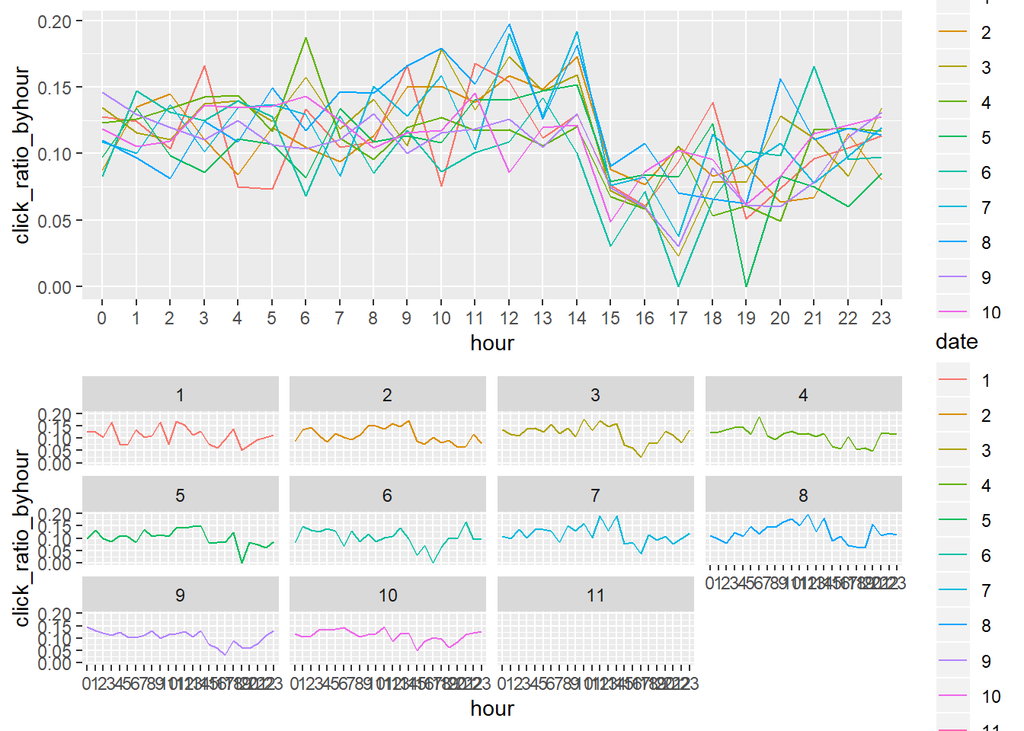

```r
plot1 <- ggplot(data1, aes(x=hour, y=click_ratio_byhour, col=date, group=date)) +geom_line()

plot2 <- plot1 + facet_wrap(~date, ncol=4)

library(gridExtra)
grid.arrange(plot1, plot2)
```

전반적으로 오후 3시~8시 사이에 시간당 클릭율이 감소하는 경향을 보임.

### (2) 시각화 그래프 1

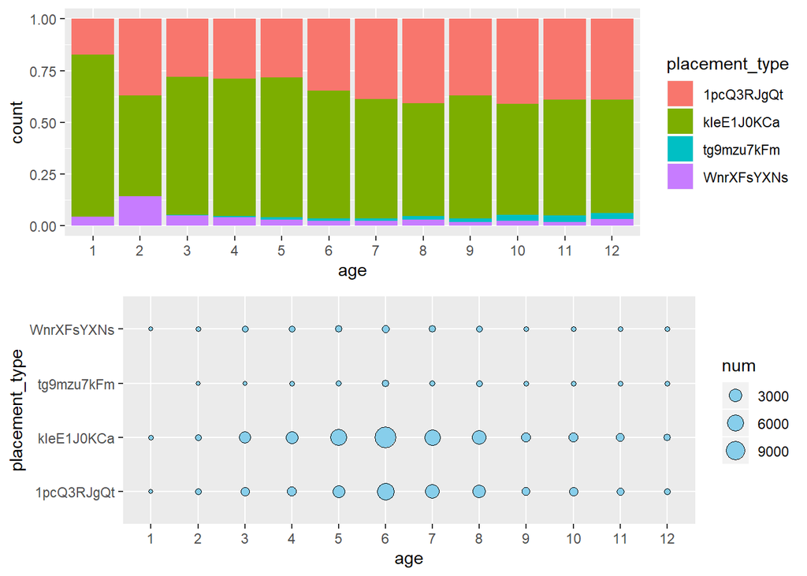

```r
plot3 <- ggplot(data1, aes(x=age, fill=placement_type)) + geom_bar(position = "fill")


# balloon plot에서 개수별로 크기 다르게 해주기 위해 age별 placement_type 개수 변수 만들기
plot_dat <- data1 %>% group_by(age, placement_type) %>% dplyr::summarise(num=n())
data1 <- left_join(data1, plot_dat, by=c("age","placement_type"))

plot4 <- ggplot(data1, aes(x=age, y=placement_type, size=num)) + geom_point(shape=21, col='black', fill="skyblue")

grid.arrange(plot3, plot4)
```

주어진 문제랑 x축 순서랑 balloon의 크기가 좀 다르긴 하지만 본질적으론 같음 ㅎㅎ

### (3) 시각화 그래프 2

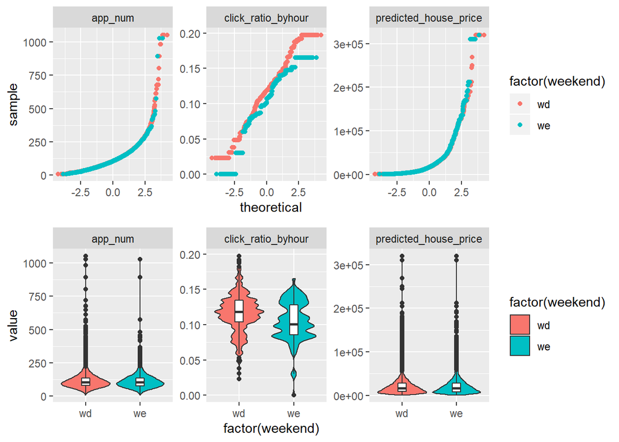

```r
# column 기준으로 facet_wrap 해주기 위해서 gather 함수를 이용해 long data로 만들어줌
plot_dat <- data1 %>% select(weekend, app_num, predicted_house_price, click_ratio_byhour)
plot_dat2 <- plot_dat %>% gather('column', 'value', 2:4)
plot_dat2$column %<>% as.factor()

plot5 <- ggplot(plot_dat2, aes(sample=value, col=factor(weekend))) + geom_qq() + facet_wrap(~column, scales="free")

plot6 <- ggplot(plot_dat2, aes(factor(weekend), value, fill=factor(weekend))) + geom_violin() +
  geom_boxplot(width=0.15,fill="white", show.legend = F) + facet_wrap(~column, scales="free")

grid.arrange(plot5, plot6)
```

이것도 그래프 순서가 좀 다르지만 본질적으론 같음 ㅎㅎ

평균적으로 주중일 때 클릭율이 더 높음